# R Tutorial on decomposing regression coefficients into case-specific contributions

Simone Rambotti

2022-08-02

## What regression models don’t show us

Regression analysis is the dominant method in quantitative social science. It comes in many variants and flavors as well as assumptions and limitations. Notwithstanding these limitations, it does its job well, that is: it shows the effect of a predictor on an outcome, net of many forms of controls (other variables, time, space, you name it.)

What regression models usually don’t show us is the cases. That is okay, sometimes. After all, cases are supposed to be a random sample of a given population, and researchers may not be interested in the peculiar characteristics of given cases. In reality, though, cases matter. Outliers and influential cases have a strong effect on the regression coefficients. These cases are neither errors nor noise. They can have substantive and theoretical importance, especially when they aren’t simple random subsets of a population. A case in point is macro-comparative research, where regression analysis is routinely used to assess relationships that occur among an often limited number of countries or states. In these analyses, “[*Comparative researchers have substantive interest in cases, but cases are largely rendered invisible in regression analysis.*](https://journals.sagepub.com/doi/full/10.1177/2378023120906064)” Here, I use a methodology, developed by University of Arizona Regents Professor of Sociology [Ronald Breiger](http://www.u.arizona.edu/~breiger/) and his colleagues ([Breiger et al., 2011](https://link.springer.com/chapter/10.1007/978-3-642-19656-0_5); [Breiger and Melamed, 2014](https://www.emerald.com/insight/content/doi/10.1108/S0733-558X%282014%290000040013/full/html); [Melamed, Breiger, and Schoon, 2012](https://journals.sagepub.com/doi/abs/10.1177/0049124112464870); [Melamed, Schoon, et al., 2012](https://link.springer.com/chapter/10.1007/978-3-642-29047-3_8); [Rambotti and Breiger, 2020](https://journals.sagepub.com/doi/full/10.1177/2378023120906064); Schoon, Melamed, and Breiger, Forthcoming), which represents an innovative way to address this issue.

## Background

I started working on this line of research as a doctoral student at the University of Arizona. My research broadly focused on income inequality and health. I was interested in making sense of why results in this area were often inconsistent. I was exposed to the groundbreaking work of Ron Breiger, which used matrix algebra to *Turn Regression Inside Out* (I like to call it TRIO), and decided to apply it to my research. In particular, I used it with a small data set of 20 rich democracies, with information on each country’s life expectancy, income inequality, and relative poverty. This work ended up being part of my dissertation and it was published as a co-authored paper with Ron Breiger on [*Socius*](https://journals.sagepub.com/doi/full/10.1177/2378023120906064).

In the paper, we used a mix of base R and Stata. Below, I will replicate part of the analysis and plots using tidyverse. This may be useful to researchers who are interested in applying this methodology to their work. If you do so, please cite the following paper:

Rambotti, Simone, and Ronald L. Breiger. 2020 “Extreme and Inconsistent: A Case-Oriented Regression Analysis of Health, Inequality, and Poverty.” *Socius* 6:1–13. DOI: 10.1177/2378023120906064.

## Data

Let’s start with the data. I collected data on 20 countries. I have data on income inequality (zinequality), relative poverty (zpoverty), the interaction of income inequality and poverty (zinteraction), and life expectancy (zlife). To ease the interpretation of the analysis, these variables are standardized. I also have the unstandardized version of life expectancy (life), which I will use in the plots.

```r
zinequality <- c(1.1244433,-0.50872159,-0.67766958,0.091982834,0.16707116,
                 -0.2271411,-0.90293348,0.035666954,-1.33469,0.073210754,
                 1.2558472,0.52373892,0.41110712,0.95549536,0.86163527,
                 -1.5787259,-0.15205313,-1.2408297,-1.1657417,2.2883074)
zpoverty <- c(-0.037866674,-0.76168096,-0.67732799,0.81118757,-0.44784385,
              -0.60439408,-1.1635544,0.82629001,-1.1013026,-0.52556658,
              -0.10601201,0.48003793,0.1916173,2.4566219,0.51871502,
              0.40452552,-0.66222554,-0.6600154,-1.0563636,2.1151583)
zinteraction <- c(-0.56928205,-0.21050778,-0.15084223,-0.47151417,-0.5961802,
                  -0.41923466,0.34269899,-0.50917506,0.69248253,-0.56586009,
                  -0.64482725,-0.32402161,-0.46804377,1.4244366,-0.16090429,
                  -1.0665343,-0.4497588,0.1494517,0.49355826,3.5040584)
zlife <- c(0.47719216,-0.15906498,0.11362062,0.56809199,0.38629928,
           -0.34085077,-1.8860576,0.56809199,-0.61353636,0.2954064,
           -0.4317506,-0.34085077,-1.5224791,0.47719216,0.022720795,
           2.6586561,-0.34085077,0.20451351,1.2952421,-1.4315863)
life <- c(79.2,78.5,78.8,79.3,79.1,78.3,76.6,79.3,78,79,78.2,78.3,77,
          79.2,78.7,81.6,78.3,78.9,80.1,77.1)
nations <- c("AUS", "AUT", "BEL", "CAN", "CHE", "DEU", "DNK" ,"ESP", "FIN", "FRA",
             "GBR" ,"GRC" ,"IRL", "ISR", "ITA", "JPN" ,"NLD" ,"NOR", "SWE", "USA")
mydata <- cbind(zinequality, zpoverty, zinteraction, zlife, life)
rownames(mydata) <- nations
mydata <- as.data.frame(mydata)
```

We can see a preview of the data set:

```r
head(mydata)
```

```
##     zinequality    zpoverty zinteraction      zlife life
## AUS  1.12444330 -0.03786667   -0.5692820  0.4771922 79.2
## AUT -0.50872159 -0.76168096   -0.2105078 -0.1590650 78.5
## BEL -0.67766958 -0.67732799   -0.1508422  0.1136206 78.8
## CAN  0.09198283  0.81118757   -0.4715142  0.5680920 79.3
## CHE  0.16707116 -0.44784385   -0.5961802  0.3862993 79.1
## DEU -0.22714110 -0.60439408   -0.4192347 -0.3408508 78.3
```

We can also see the summary of the variables:

```r
summary(mydata)
```

```
##   zinequality          zpoverty        zinteraction         zlife
##  Min.   :-1.57873   Min.   :-1.1636   Min.   :-1.0665   Min.   :-1.88606
##  1st Qu.:-0.73399   1st Qu.:-0.6660   1st Qu.:-0.5233   1st Qu.:-0.36358
##  Median : 0.05444   Median :-0.2769   Median :-0.3716   Median : 0.06817
##  Mean   : 0.00000   Mean   : 0.0000   Mean   : 0.0000   Mean   : 0.00000
##  3rd Qu.: 0.60821   3rd Qu.: 0.4897   3rd Qu.: 0.1978   3rd Qu.: 0.47719
##  Max.   : 2.28831   Max.   : 2.4566   Max.   : 3.5041   Max.   : 2.65866
##       life
##  Min.   :76.60
##  1st Qu.:78.28
##  Median :78.75
##  Mean   :78.67
##  3rd Qu.:79.20
##  Max.   :81.60
```

As you can see, the summary function doesn’t show the n and standard deviation, which I find unfortunate. We can get them with the following code:

```r
library(dplyr)
myn <- mydata %>%
  summarise_all(list(n = ~ n()))
mysd <- mydata %>%
  summarise_all(list(sd = ~ sd(.)))
t(myn)
```

```
##                [,1]
## zinequality_n    20
## zpoverty_n       20
## zinteraction_n   20
## zlife_n          20
## life_n           20
```

```r
t(mysd)
```

```
##                     [,1]
## zinequality_sd  1.000000
## zpoverty_sd     1.000000
## zinteraction_sd 1.000000
## zlife_sd        1.000000
## life_sd         1.100179
```

EDIT: I recently encountered the `vtable` package, which I really like. One line of code gives me everything I want:

```r
library(vtable)
st(mydata, add.median = T, digits = 1, out = "return")
```

```
##       Variable  N Mean Std. Dev.  Min Pctl. 25 Pctl. 50 Pctl. 75  Max
## 1  zinequality 20    0         1 -1.6     -0.7      0.1      0.6  2.3
## 2     zpoverty 20    0         1 -1.2     -0.7     -0.3      0.5  2.5
## 3 zinteraction 20    0         1 -1.1     -0.5     -0.4      0.2  3.5
## 4        zlife 20    0         1 -1.9     -0.4      0.1      0.5  2.7
## 5         life 20 78.7       1.1 76.6     78.3     78.8     79.2 81.6
```

As we can see, we have no missing information. The average life expectancy among these 20 rich democracies was 78.7 (in 2004). The standard deviation is 1.1 and the range is 5. Is there enough variation? *Yes*. To put things in perspective, a [2013 study from the National Center for Health Statistics estimates](https://www.cdc.gov/nchs/data/nvsr/nvsr61/nvsr61_09.pdf) that the “*elimination of heart disease would increase life expectancy at birth by almost 4 years, and elimination of cancer by more than 3 years*” (cited by [Lane Kenworthy](https://en.wikipedia.org/wiki/Lane_Kenworthy) in [his piece on longevity](https://lanekenworthy.net/longevity/#fn-12377-43), which I highly recommend).

A histogram (below) reveals that in most countries, life expectancy falls somewhere in the middle of the distribution, with a few extreme values on both sides. As we’ll see later, this will be an important point.

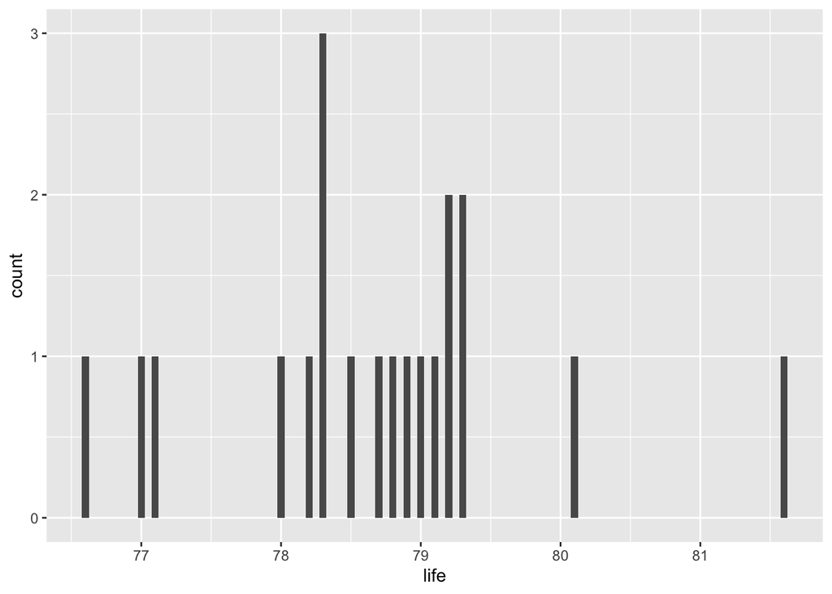

```r
library(ggplot2)
 ggplot(mydata, aes(x=life)) +
   geom_histogram(binwidth = 0.05)
```

## Analysis

Now, it’s time to do some analysis. The plan is following:

1. Estimate OLS regression models
2. Turn those regression models “inside out”

## OLS regression models

The first model uses inequality to predict life expectancy:

```r
ols1 <- lm(zlife ~ zinequality - 1, data = mydata)
summary(ols1)
```

```
##
## Call:
## lm(formula = zlife ~ zinequality - 1, data = mydata)
##
## Residuals:
##      Min       1Q   Median       3Q      Max
## -2.20720 -0.40161 -0.05625  0.58579  2.09715
##
## Coefficients:
##             Estimate Std. Error t value Pr(>|t|)
## zinequality  -0.3557     0.2144  -1.659    0.114
##
## Residual standard error: 0.9346 on 19 degrees of freedom
## Multiple R-squared:  0.1265, Adjusted R-squared:  0.08053
## F-statistic: 2.752 on 1 and 19 DF,  p-value: 0.1136
```

The second model uses poverty:

```r
ols2 <- lm(zlife ~ zpoverty - 1, data = mydata)
summary(ols2)
```

```
##
## Call:
## lm(formula = zlife ~ zpoverty - 1, data = mydata)
##
## Residuals:
##      Min       1Q   Median       3Q      Max
## -1.80958 -0.38550  0.07338  0.43172  2.63207
##
## Coefficients:
##          Estimate Std. Error t value Pr(>|t|)
## zpoverty  0.06572    0.22892   0.287    0.777
##
## Residual standard error: 0.9978 on 19 degrees of freedom
## Multiple R-squared:  0.00432,    Adjusted R-squared:  -0.04808
## F-statistic: 0.08243 on 1 and 19 DF,  p-value: 0.7771
```

The third model uses inequality *and* poverty:

```r
ols3 <- lm(zlife ~ zinequality + zpoverty - 1, data = mydata)
summary(ols3)
```

```
##
## Call:
## lm(formula = zlife ~ zinequality + zpoverty - 1, data = mydata)
##
## Residuals:
##      Min       1Q   Median       3Q      Max
## -1.89689 -0.25301 -0.04308  0.57066  1.32137
##
## Coefficients:
##             Estimate Std. Error t value Pr(>|t|)
## zinequality  -0.7319     0.2673  -2.738   0.0135 *
## zpoverty      0.5587     0.2673   2.090   0.0511 .
## ---
## Signif. codes:  0 '***' 0.001 '**' 0.01 '*' 0.05 '.' 0.1 ' ' 1
##
## Residual standard error: 0.8614 on 18 degrees of freedom
## Multiple R-squared:  0.297,  Adjusted R-squared:  0.2189
## F-statistic: 3.803 on 2 and 18 DF,  p-value: 0.04191
```

The fourth model uses inequality, poverty, *and* their interaction:

```r
ols4 <- lm(zlife ~ zinequality + zpoverty + zinteraction - 1, data = mydata)
summary(ols4)
```

```
##
## Call:
## lm(formula = zlife ~ zinequality + zpoverty + zinteraction -
##     1, data = mydata)
##
## Residuals:
##      Min       1Q   Median       3Q      Max
## -1.61723 -0.25239 -0.03178  0.28936  1.54345
##
## Coefficients:
##              Estimate Std. Error t value Pr(>|t|)
## zinequality   -0.6754     0.2379  -2.839  0.01133 *
## zpoverty       0.7525     0.2497   3.013  0.00783 **
## zinteraction  -0.4876     0.1999  -2.439  0.02596 *
## ---
## Signif. codes:  0 '***' 0.001 '**' 0.01 '*' 0.05 '.' 0.1 ' ' 1
##
## Residual standard error: 0.7629 on 17 degrees of freedom
## Multiple R-squared:  0.4793, Adjusted R-squared:  0.3874
## F-statistic: 5.216 on 3 and 17 DF,  p-value: 0.00977
```

A few comments: first, notice how I estimate the model using the `- 1` option. This option omits the constant, which in my case would be equal to 0, as the variables are standardized. Second, the explained variation (r-squared) increases remarkably from model 1 to model 4, where we see a significant interaction between income inequality and poverty. A thorough explanation of these models is beyond the scope here. It may be sufficient to cite the [article](https://journals.sagepub.com/doi/full/10.1177/2378023120906064):

> “A substantive interpretation of this result … is that higher income inequality is associated with lower life expectancy only in high-poverty countries (i.e., countries whose standardized measure of poverty is above zero). By way of contrast, income inequality is completely unrelated to life expectancy in low-poverty countries (the 12 countries in our sample whose standardized measure of poverty is below zero).”

If you want to know more, you can check my previous publication on [*Social Science & Medicine*](https://doi.org/10.1016/j.socscimed.2015.02.026), which is freely accessible [here](https://doi.org/10.31235/osf.io/mre7c).

As noted by [Lane Kenworthy](https://scholar.google.com/scholar?q=Toward+Improved+Use+of+Regression+in+Macro-comparative+Analysis&hl=en&as_sdt=0&as_vis=1&oi=scholart), “in the prototypical quantitative macro-comparative article, the regressions are the starting and ending point of the analysis. I would like to see more papers in which regression is used to inform discussion of cases.” That is what Ron Breiger and I did in [our paper](https://journals.sagepub.com/doi/full/10.1177/2378023120906064). Below, I show how.

## Turning the regression models inside out

Now it’s time to turn the regression coefficients “inside out,” that is, to decompose the regression coefficients we have seen above into case-specific contributions. First, let’s quickly go over the mathematical foundations of this methodology.

Equation 1 (below) is the typical representation of the regression model, where $\hat{y}$ is a vector of values on the outcome, as predicted by a matrix of independent variables $X$ and a vector of coefficients $b$.

$$\begin{align*}
\hat{y} = Xb
\end{align*}$$

Equation 2 (below) is a well-known formula representing the same regression model. In this formula, $y$ is the vector of observed outcome scores. This formula returns the regression coefficient as we’re used to seeing it.

$$\begin{align*}
b = (X^{T}X)^{-1}X^{T}y
\end{align*}$$

Notice: $X^{T}$ is the transpose of matrix $X$, while the superscript $^{-1}$ indicates the inverse of a matrix.

The key to decomposing the regression coefficient into case-specific contributions is to replace the observed outcome scores ($y$) with a diagonal matrix having the observed outcome as the main diagonal and zeroes in the other cells. In other words, we must use equation 3 (below), where $Y=diag(y)$:

$$\begin{align*}
b = (X^{T}X)^{-1}X^{T}Y
\end{align*}$$

This equation, instead of returning one regression coefficient per independent variable, will return a list of case-specific contributions to the regression coefficients. If you sum all these numbers up, you get the regression coefficients! This is pretty cool! As Ron Breiger keeps saying, this method shows that OLS regression coefficients can be seen as “sums across cases.” What is also cool is that the procedure is pretty simple with R. Let’s see.

I’m going to start with the first regression model, which uses income inequality as the only predictor of life expectancy. As a reminder, the coefficient is -0.36 (Notice: the coefficient is not statistically significant, and something can be said about using a non-default standard error, but this is not important here. The paper discusses these considerations.)

```r
ols1
```

```
##
## Call:
## lm(formula = zlife ~ zinequality - 1, data = mydata)
##
## Coefficients:
## zinequality
##     -0.3557
```

Now, let’s apply equation 3: $b = (X^{T}X)^{-1}X^{T}Y$. First, let’s define the elements of the equation. $X$ is the matrix of independent variables, in this case, inequality. We can see it using the following code `mydata$zinequality`. Let’s see just the first three values:

```r
mydata$zinequality[1:3]
```

```
## [1]  1.1244433 -0.5087216 -0.6776696
```

Even more conveniently, especially when using more than one independent variable, is to use the following code: `model.matrix(ols1)`. Let’s see the first three values:

```r
X1 <- model.matrix(ols1)
X1[1:3]
```

```
## [1]  1.1244433 -0.5087216 -0.6776696
```

Excellent. Now, we need $Y$, which is a diagonal matrix containing the observed values on the outcome in the main diagonal (and zeros elsewhere). Let’s see the first three values of the observed outcome:

```r
mydata$zlife[1:3]
```

```
## [1]  0.4771922 -0.1590650  0.1136206
```

Now, let’s create the diagonal matrix and see the first three rows and columns:

```r
Y <- diag(mydata$zlife)
Y[1:3, 1:3]
```

```
##           [,1]      [,2]      [,3]
## [1,] 0.4771922  0.000000 0.0000000
## [2,] 0.0000000 -0.159065 0.0000000
## [3,] 0.0000000  0.000000 0.1136206
```

Perfect. We have all the elements to finally turn the regression coefficient inside out! Again, we’re applying equation 3: $b = (X^{T}X)^{-1}X^{T}Y$

```r
b_case1 <- solve(crossprod(X1)) %*% t(X1) %*% Y
```

Notice: the function `crossprod` multiplies a transposed matrix by its original, that is: `crossprod(X1)` is equivalent to `t(X1) %*% X1`. Instead, `solve` is the function to compute the inverse matrix.

Okay, let’s focus: we did turn the regression coefficient inside out! Do you want to see what that looks like? First, let’s see again the coefficient as computed by the `lm` function. To keep things a little cleaner, I will round to 3 decimals:

```r
round(ols1$coefficients, 3)
```

```
## zinequality
##      -0.356
```

Now, let’s see the case-specific contributions!

```r
round(b_case1, 3)
```

```
##              [,1]  [,2]   [,3]  [,4]  [,5]  [,6] [,7]  [,8]  [,9] [,10]  [,11]
## zinequality 0.028 0.004 -0.004 0.003 0.003 0.004 0.09 0.001 0.043 0.001 -0.029
##              [,12]  [,13] [,14] [,15]  [,16] [,17]  [,18]  [,19]  [,20]
## zinequality -0.009 -0.033 0.024 0.001 -0.221 0.003 -0.013 -0.079 -0.172
```

Okay, that’s not very intuitive. What are we looking at?

```r
dim(b_case1)
```

```
## [1]  1 20
```

Okay, that’s a 1 by 20 matrix, where 1 is the number of predictors (income inequality) and 20 is the number of observations (20 countries). Maybe it would help to transpose:

```r
round(t(b_case1), 3)
```

```
##       zinequality
##  [1,]       0.028
##  [2,]       0.004
##  [3,]      -0.004
##  [4,]       0.003
##  [5,]       0.003
##  [6,]       0.004
##  [7,]       0.090
##  [8,]       0.001
##  [9,]       0.043
## [10,]       0.001
## [11,]      -0.029
## [12,]      -0.009
## [13,]      -0.033
## [14,]       0.024
## [15,]       0.001
## [16,]      -0.221
## [17,]       0.003
## [18,]      -0.013
## [19,]      -0.079
## [20,]      -0.172
```

That’s better. Even better? Let’s add the case labels:

```r
cbind(rownames(mydata), round(t(b_case1), 3))
```

```
##             zinequality
##  [1,] "AUS" "0.028"
##  [2,] "AUT" "0.004"
##  [3,] "BEL" "-0.004"
##  [4,] "CAN" "0.003"
##  [5,] "CHE" "0.003"
##  [6,] "DEU" "0.004"
##  [7,] "DNK" "0.09"
##  [8,] "ESP" "0.001"
##  [9,] "FIN" "0.043"
## [10,] "FRA" "0.001"
## [11,] "GBR" "-0.029"
## [12,] "GRC" "-0.009"
## [13,] "IRL" "-0.033"
## [14,] "ISR" "0.024"
## [15,] "ITA" "0.001"
## [16,] "JPN" "-0.221"
## [17,] "NLD" "0.003"
## [18,] "NOR" "-0.013"
## [19,] "SWE" "-0.079"
## [20,] "USA" "-0.172"
```

That’s it. Those are the case-specific contributions to the regression coefficient. Ron Breiger calls them **intensities**. So, what do we see? Well, most countries have a score at or near 0. That is, they don’t contribute to the regression coefficient at all! Some countries do contribute, positively or negatively. First of all, here we are examining the relationship between income inequality and health, which we expect to be negative (inequality goes up, life expectancy goes down). A negative “intensity” means that the case contributes to the regression coefficient in the direction we expect. For example:

| Country | Intensity |
| --- | --- |
| JPN | -0.221 |
| USA | -0.172 |
| SWE | -0.079 |

Japan, the US, and Sweden strongly contribute to the coefficient. Japan and Sweden are healthy and equal. The US is unhealthy and unequal. Not only are these contributions strong, but they make sense (they meet our expectations). Question: what is going on with Denmark?

| Country | Intensity |
| --- | --- |
| DNK | 0.09 |

Denmark’s contribution is pretty strong, but it’s positive, it goes against our expectations! We know Denmark is equal… does it mean that Denmark is unhealthy? Erm… yes:

```r
summary(mydata$life)
```

```
##    Min. 1st Qu.  Median    Mean 3rd Qu.    Max.
##   76.60   78.28   78.75   78.67   79.20   81.60
```

```r
mydata["DNK","life"]
```

```
## [1] 76.6
```

```r
mydata["DNK","zlife"]
```

```
## [1] -1.886058
```

Wow! So, let’s elaborate. Out of 20 rich democracies, Denmark has the lowest life expectancy (in 2004). It’s two full years below the mean, which is almost 2 standard deviations! That deserves some scrutiny, right? Which is the point of this method. *Regression renders cases invisible, but cases matter.*

Lastly (sort of lastly): I said something about regression coefficients being sums across cases. What does it mean? First, let’s see the regression coefficient again.

```r
round(ols1$coefficients, 3)
```

```
## zinequality
##      -0.356
```

If you remember, I created an object called `b_case1` which shows the case-specific contributions to the coefficients:

```r
cbind(rownames(mydata), round(t(b_case1), 3))
```

```
##             zinequality
##  [1,] "AUS" "0.028"
##  [2,] "AUT" "0.004"
##  [3,] "BEL" "-0.004"
##  [4,] "CAN" "0.003"
##  [5,] "CHE" "0.003"
##  [6,] "DEU" "0.004"
##  [7,] "DNK" "0.09"
##  [8,] "ESP" "0.001"
##  [9,] "FIN" "0.043"
## [10,] "FRA" "0.001"
## [11,] "GBR" "-0.029"
## [12,] "GRC" "-0.009"
## [13,] "IRL" "-0.033"
## [14,] "ISR" "0.024"
## [15,] "ITA" "0.001"
## [16,] "JPN" "-0.221"
## [17,] "NLD" "0.003"
## [18,] "NOR" "-0.013"
## [19,] "SWE" "-0.079"
## [20,] "USA" "-0.172"
```

Let’s add up all these numbers:

```r
round(rowSums(b_case1), 3)
```

```
## zinequality
##      -0.356
```

And there you have it! *The sum of all those case-specific contributions is equal to the regression coefficient!* That’s regression analysis as you rarely saw it.

## Visualizing the regression models inside out

In the [paper](https://journals.sagepub.com/doi/full/10.1177/2378023120906064), Ron Breiger and I decompose the regression coefficients of all the four models seen above. We present these case-specific contributions to the regression coefficients (for brevity: *intensities*) in visual form. I’ll reproduce [Figure 2](https://journals.sagepub.com/na101/home/literatum/publisher/sage/journals/content/srda/2020/srda_6/2378023120906064/20200217/images/large/10.1177_2378023120906064-fig2.jpeg) from the paper using `ggplot2`.

First, let’s add the intensity for model 1 to the data set.

```r
b_case1 <- t(b_case1)
b_case1 <- as.data.frame(b_case1)
b_case1 <- rename(b_case1, intensity_inequality1 = zinequality)
mydata <- cbind(mydata, b_case1)
```

Now, we can create a visualization. The idea is to plot inequality (X) vs. the outcome, that is life expectancy (Y). Then, we can highlight each country’s contribution to the regression coefficient of inequality by adjusting the size of each dot.

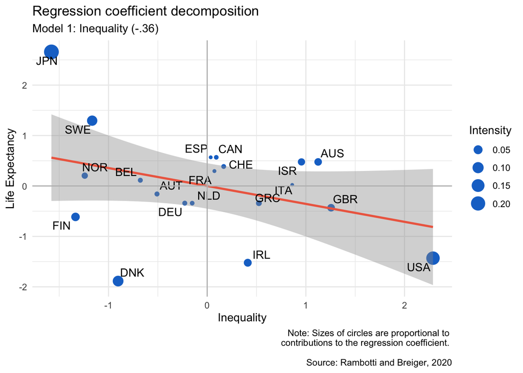

```r
library(ggrepel)
Intensity <- abs(mydata$intensity_inequality1)
myplot <- ggplot(data = mydata, aes(zinequality, zlife, label = rownames(mydata))) +
  geom_point(aes(size = Intensity), color="dodgerblue3") +
  stat_smooth(method = 'lm', color = "coral2") +
  geom_text_repel() +
    labs(title = "Regression coefficient decomposition",
       subtitle = "Model 1: Inequality (-.36)",
       x = "Inequality", y = "Life Expectancy",
       caption = "Note: Sizes of circles are proportional to
       contributions to the regression coefficient.

       Source: Rambotti and Breiger, 2020") +
  geom_hline(yintercept=0, color = "grey") +
  geom_vline(xintercept=0, color = "grey") +
  theme_minimal()

myplot
```

As we can see, most countries are around the center of the plot, with little contribution to the regression coefficients. A few countries have a larger contribution, in particular, Japan, the US, Sweden, and Denmark.

What happens in other models? Let’s see, for example, model 2. First, I will compute the intensities:

```r
X2 <- model.matrix(ols2)
b_case2 <- solve(crossprod(X2)) %*% t(X2) %*% Y
```

Let’s double-check that the result is correct:

```r
round(ols2$coefficients, 2)
```

```
## zpoverty
##     0.07
```

```r
round(rowSums(b_case2), 2)
```

```
## zpoverty
##     0.07
```

Perfect. Now, let’s add the intensities to the data:

```r
b_case2 <- t(b_case2)
b_case2 <- as.data.frame(b_case2)
b_case2 <- rename(b_case2, intensity_poverty2 = zpoverty)
mydata <- cbind(mydata, b_case2)
```

And now, we can build our plot, which reproduces [Figure 3](https://journals.sagepub.com/na101/home/literatum/publisher/sage/journals/content/srda/2020/srda_6/2378023120906064/20200217/images/large/10.1177_2378023120906064-fig3.jpeg) in the [paper](https://journals.sagepub.com/doi/full/10.1177/2378023120906064).

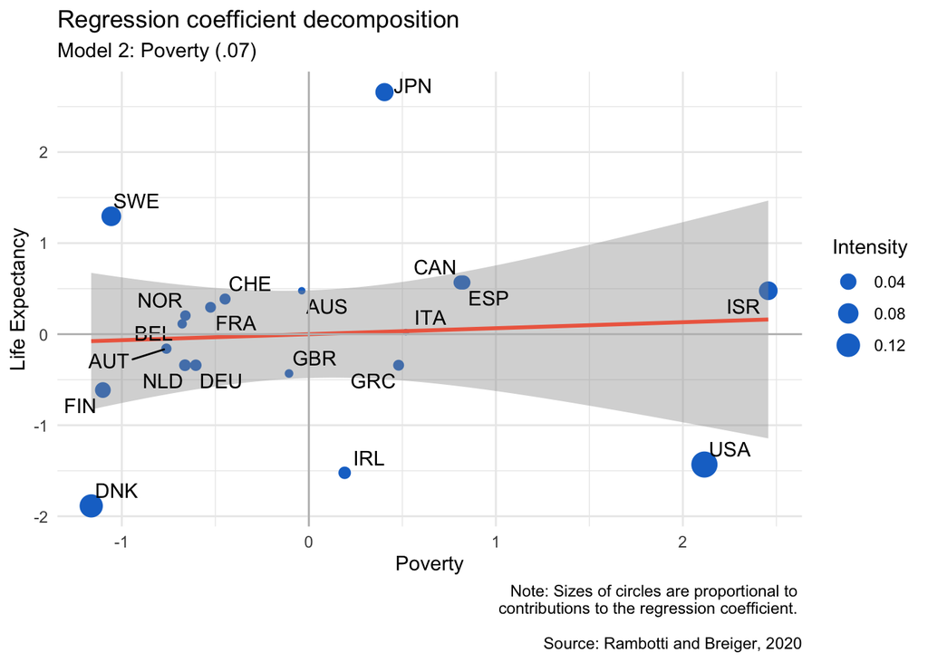

```r
Intensity <- abs(mydata$intensity_poverty2)
myplot <- ggplot(data = mydata, aes(zpoverty, zlife, label = rownames(mydata))) +
  geom_point(aes(size = Intensity), color="dodgerblue3") +
  stat_smooth(method = 'lm', color = "coral2") +
  geom_text_repel() +
    labs(title = "Regression coefficient decomposition",
       subtitle = "Model 2: Poverty (.07)",
       x = "Poverty", y = "Life Expectancy",
       caption = "Note: Sizes of circles are proportional to
       contributions to the regression coefficient.

       Source: Rambotti and Breiger, 2020") +
  geom_hline(yintercept=0, color = "grey") +
  geom_vline(xintercept=0, color = "grey") +
  theme_minimal()

myplot
```

Let’s see the last model. In particular, let’s visualize the interaction regression coefficient. Let’s start by computing the intensities for model 4:

```r
X4 <- model.matrix(ols4)
b_case4 <- solve(crossprod(X4)) %*% t(X4) %*% Y
```

And let’s double-check that our work is correct:

```r
round(ols4$coefficients, 2)
```

```
##  zinequality     zpoverty zinteraction
##        -0.68         0.75        -0.49
```

```r
round(rowSums(b_case4), 2)
```

```
##  zinequality     zpoverty zinteraction
##        -0.68         0.75        -0.49
```

Excellent. Now, let’s add these intensities to the data:

```r
b_case4 <- t(b_case4)
b_case4 <- as.data.frame(b_case4)
b_case4 <- rename(b_case4, intensity_inequality4 = zinequality,
                  intensity_poverty4 = zpoverty,
                  intensity_interaction4 = zinteraction)
mydata <- cbind(mydata, b_case4)
```

We want to reproduce [Figure 5](https://journals.sagepub.com/na101/home/literatum/publisher/sage/journals/content/srda/2020/srda_6/2378023120906064/20200217/images/large/10.1177_2378023120906064-fig5.jpeg) from the [paper](https://journals.sagepub.com/doi/full/10.1177/2378023120906064). Because this is a multiple regression model, we need to go through some extra steps.

We want to see how the coefficient of the interaction is decomposed across case-specific contributions. Now, in the previous plots, we simply looked at X (e.g. income inequality) vs. Y (life expectancy). That was pretty straightforward because we were only using one independent variable at the time.

Here, the effect of the interaction is net of the main effects of the two other independent variables, that is, income inequality and poverty. If we want to reproduce the effect of the interaction in that model and plot it, we must calculate the residualized interaction scores. How do we get them? Three steps:

1. Estimate a regression model where the interaction is predicted by inequality and poverty
2. Compute the residuals of this model. These residuals will be our X.
3. Use the residuals to predict the outcome (life expectancy).

Step 1:

```r
model_for_interaction_residuals <- lm(zinteraction ~ zinequality + zpoverty, data = mydata)
```

Step 2:

```r
interaction_residuals <- resid(model_for_interaction_residuals)
```

Step 3:

```r
interaction_residuals <- as.matrix(interaction_residuals)
mydata <- cbind(mydata, interaction_residuals)
interaction_residuals_predicting_life_exp_model <-
  lm(zlife ~ interaction_residuals - 1, data = mydata)
summary(interaction_residuals_predicting_life_exp_model)
```

```
##
## Call:
## lm(formula = zlife ~ interaction_residuals - 1, data = mydata)
##
## Residuals:
##     Min      1Q  Median      3Q     Max
## -1.8111 -0.4173  0.0651  0.1842  2.1495
##
## Coefficients:
##                       Estimate Std. Error t value Pr(>|t|)
## interaction_residuals  -0.4876     0.2369  -2.058   0.0536 .
## ---
## Signif. codes:  0 '***' 0.001 '**' 0.01 '*' 0.05 '.' 0.1 ' ' 1
##
## Residual standard error: 0.9043 on 19 degrees of freedom
## Multiple R-squared:  0.1823, Adjusted R-squared:  0.1392
## F-statistic: 4.235 on 1 and 19 DF,  p-value: 0.05358
```

Now, let’s double-check that this is indeed the effect of the interaction term on life expectancy in model 4, that is, net of inequality and poverty:

```r
round(ols4$coefficients, 4)
```

```
##  zinequality     zpoverty zinteraction
##      -0.6754       0.7525      -0.4876
```

```r
round(interaction_residuals_predicting_life_exp_model$coefficients, 4)
```

```
## interaction_residuals
##               -0.4876
```

All good! We can now build our plot, which will reproduce [Figure 5](https://journals.sagepub.com/na101/home/literatum/publisher/sage/journals/content/srda/2020/srda_6/2378023120906064/20200217/images/large/10.1177_2378023120906064-fig5.jpeg) from the [paper](https://journals.sagepub.com/doi/full/10.1177/2378023120906064).

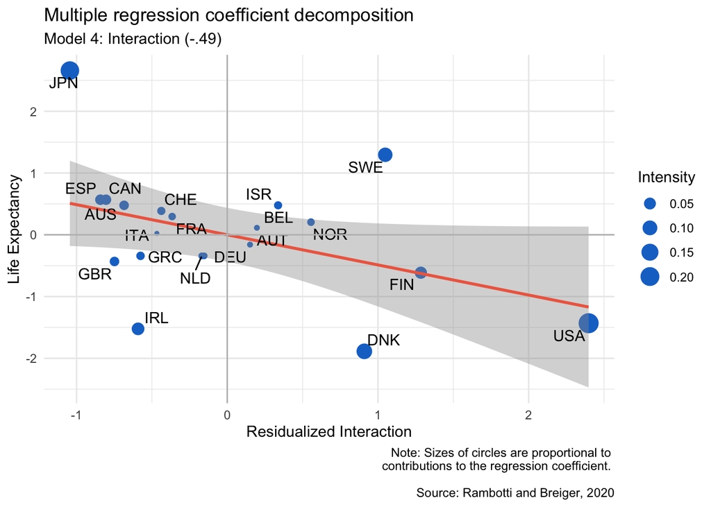

```r
Intensity <- abs(mydata$intensity_interaction4)
myplot <- ggplot(data = mydata, aes(interaction_residuals, zlife,
                                    label = rownames(mydata))) +
  geom_point(aes(size = Intensity), color="dodgerblue3") +
  stat_smooth(method = 'lm', color = "coral2") +
  geom_text_repel() +
    labs(title = "Multiple regression coefficient decomposition",
       subtitle = "Model 4: Interaction (-.49)",
       x = "Residualized Interaction", y = "Life Expectancy",
       caption = "Note: Sizes of circles are proportional to
       contributions to the regression coefficient.

       Source: Rambotti and Breiger, 2020") +
  geom_hline(yintercept=0, color = "grey") +
  geom_vline(xintercept=0, color = "grey") +
  theme_minimal()

myplot
```

Once again, a small handful of cases (Japan, USA, Sweden, and Denmark) are the major contributor to the regression coefficient. To cite the [paper](https://journals.sagepub.com/doi/full/10.1177/2378023120906064):

> These four countries, then, dominate the case-specific contributions to the regression coefficients in every model that estimates the effect of income inequality, poverty—individually or simultaneously considered—and their interaction on life expectancy.

## Learning from influential cases

These four countries are highly influential cases. What can we learn from influential cases? We can learn a lot. The final part of the paper is a more in-depth analysis of Denmark and Japan. These two countries have “values on the outcome that are extreme in magnitude and inconsistent with conventional theoretical expectations.” Why inconsistent? Denmark has a lower life expectancy than we would expect based on its inequality, and Japan has a longer life expectancy than we would expect based on its poverty rate. These countries have specific trajectories.

Denmark’s longevity is affected by “the high risk for mortality for women born between the two world wars.” It’s still quite unclear why, but “Interwar Danish women exhibited high rates of smoking throughout their life course and smoked more than women in any other European country.” This explanation is consistent with evidence suggesting that Denmark’s life expectancy is on the rise as interwar women (born from 1915 to 1945) are passing away.

Japan experienced a dramatic rise in life expectancy after WWII: “In 1947, life expectancy in Japan was approximately 20 years lower than in Sweden and most Western European nations; by 1990, the Japanese were living longer than any other people.” There are several reasons for that, the first being the “government’s strong stewardship in investing in key interventions for public health” (Ikeda et al. 2011:1094). Feel free to look at the [paper](https://journals.sagepub.com/doi/10.1177/2378023120906064) if you want to know more.

## Conclusion

In sum, this methodology developed by Breiger and colleagues ([Breiger et al., 2011](https://link.springer.com/chapter/10.1007/978-3-642-19656-0_5); [Breiger and Melamed, 2014](https://www.emerald.com/insight/content/doi/10.1108/S0733-558X%282014%290000040013/full/html); [Melamed, Breiger, and Schoon, 2012](https://journals.sagepub.com/doi/abs/10.1177/0049124112464870); [Melamed, Schoon, et al., 2012](https://link.springer.com/chapter/10.1007/978-3-642-29047-3_8); [Rambotti and Breiger, 2020](https://journals.sagepub.com/doi/full/10.1177/2378023120906064); Schoon, Melamed, and Breiger, Forthcoming) allows researchers to turn regression coefficients “inside out.” This means that researchers can decompose regression coefficients into case-specific contributions, thus uncovering a “variety of stories lying underneath regression analysis.”

There is much more to this method, and if you want to learn more, I encourage you to look at the literature linked in the paragraph above. For example, it’s worth noticing that it can be used also with individual-level data. In fact, as we write in the paper, “the ultimate goal should not be to simply pinpoint single outliers but to uncover the overall patterning of contributions across all the cases, including clusters of individuals.” David Melamed, Ron Breiger, and Eric Schoon successfully did that in [this study](https://journals.sagepub.com/doi/abs/10.1177/0049124112464870), which uses GSS data. This approach can be useful to detect clusters of cases inductively and use this information to advance sociological theory.

In the meantime, I hope that this tutorial will be useful to researchers who are interested to apply this methodology to their work.

## References

Breiger, Ronald L., Gary A. Ackerman, Victor Asal, David Melamed, H. Brinton Milward, R. Karl Rethemeyer, and Eric Schoon. 2011. “Application of a Profile Similarity Methodology for Identifying Terrorist Groups That Use or Pursue CBRN Weapons.” Pp. 26–33 in *Social Computing, Behavioral-Cultural Modeling and Prediction: 4th International Conference, SBP 2011, College Park, MD, USA, March 29-31, 2011. Proceedings*, edited by J. Salerno, S. J. Yang, D. Nau, and S.-K. Chai. Berlin, Heidelberg: Springer Berlin Heidelberg.

Breiger, Ronald L., and David Melamed. 2014. “The Duality of Organizations and Their Attributes: Turning Regression Modeling ‘Inside Out.’” *Research in the Sociology of Organizations* 40:263–75.

Melamed, David, Ronald L. Breiger, and Eric Schoon. 2012. “The Duality of Clusters and Statistical Interactions.” *Sociological Methods & Research* 42(1):41–59. doi: 10.1177/0049124112464870.

Melamed, David, Eric Schoon, Ronald L. Breiger, Victor Asal, and R. Karl Rethemeyer. 2012. “Using Organizational Similarity to Identify Statistical Interactions for Improving Situational Awareness of CBRN Activities.” Pp. 61–68 in *Social Computing, Behavioral - Cultural Modeling and Prediction, Lecture Notes in Computer Science*, edited by S. J. Yang, A. M. Greenberg, and M. Endsley. Springer Berlin Heidelberg.

Rambotti, Simone, and Ronald L. Breiger. 2020. “Extreme and Inconsistent: A Case-Oriented Regression Analysis of Health, Inequality, and Poverty.” *Socius* 6:2378023120906064. doi: 10.1177/2378023120906064.

Schoon, Eric, David Melamed, and Ronald L. Breiger. Forthcoming. *Regression Inside Out*. Cambridge, England: Cambridge University Press.